# Uncertainty estimation of predictions outputs from PLS-DA applied to 2D simulations

Helder Carneiro

## Overview

This Rmarkdown documents contains the code and 2D simulations of the error propagation and classification uncertainty estimation using Monte Carlo simulations for two generic classes with linear separation classified with PLS-DA.

#### Packages

```r
windowsFonts(A = windowsFont("DejaVu Sans"))
palette("Tableau10")

library(caret) #classification using train()
#library(kernlab)
library(MASS) #generate the samples and calculate the augmented noise
library(dplyr) #data handling
library(knitr) #knit options for the Rmarkdown report
library(kableExtra) #table options
```

#### Local sources files containing the functions

```r
source("predict_with_uncertainty_parallel_v4.R")
source("plot_functions.R")
```

#### 2D simulations with linear separation pattern

```r
set.seed(1234)
n_points <- 10  # Number of points per class
n_replicates <- 5  # Number of replicates
noise_sd <- 0.1  # Standard deviation
rho <- 0 # Correlation coefficient

# Define the covariance matrix
cov_matrix <- matrix(c(noise_sd^2, rho * noise_sd^2,
                       rho * noise_sd^2, noise_sd^2), nrow = 2)

# Function to generate 2D points with correlated noise
generate_class <- function(n_points, n_replicates, center_x, center_y, cov_matrix) {
  points <- matrix(0, nrow = n_points * n_replicates, ncol = 2)

  for (i in 1:n_points) {
    base_point <- c(center_x + rnorm(1, 0, 0.2), center_y + rnorm(1, 0, 0.2))

    for (j in 1:n_replicates) {
      noise <- mvrnorm(1, mu = c(0, 0), Sigma = cov_matrix)  # Correlated noise
      points[(i - 1) * n_replicates + j, ] <- base_point + noise
    }
  }
  return(points)
}

class1 <- generate_class(n_points, n_replicates, center_x = 0.8, center_y = 1.6, cov_matrix)
class2 <- generate_class(n_points, n_replicates, center_x = 1.3, center_y = 1.2, cov_matrix)

data <- data.frame(
  Class = factor(rep(c("Class 1", "Class 2"), each = n_points * n_replicates)),
  Sample_ID = rep(1:(2 * n_points), each = n_replicates),
  X1 = c(class1[, 1], class2[, 1]),
  X2 = c(class1[, 2], class2[, 2])
)

# Mean center the data
data$X1 <- data$X1 - mean(data$X1)
data$X2 <- data$X2 - mean(data$X2)

# Calculate the mean and standard deviation of each sample
mean_data <- aggregate(cbind(X1, X2) ~ Class + Sample_ID, data = data, FUN = mean)
sd_data <- aggregate(cbind(X1, X2) ~ Class + Sample_ID, data = data, FUN = sd)

rm(class1, class2)
```

#### Fitting the PLS-DA model

```r
pls_model <- train(y = mean_data$Class,
                   x = mean_data[,3:4],
                   method = "pls")
pls_model
```

```
## Partial Least Squares
##
## 20 samples
##  2 predictor
##  2 classes: 'Class 1', 'Class 2'
##
## No pre-processing
## Resampling: Bootstrapped (25 reps)
## Summary of sample sizes: 20, 20, 20, 20, 20, 20, ...
## Resampling results:
##
##   Accuracy   Kappa
##   0.9473016  0.8804084
##
## Tuning parameter 'ncomp' was held constant at a value of 1
```

## Local uncertainty

The `predict_with_uncertainty_parallel()` function is used to estimate the uncertainty of each sample.

```r
loc_pred <- predict_with_uncertainty(data[,-1],
                                                pls_model,
                                                n_sim = 500,
                                                return_simulations = T)
```

This function returns the mean and standard deviation of the $\hat{y}$ of each sample based on the Monte Carlo simulation. It also returns the area above and bellow the decision boundary (in this case, zero) of each sample. The classification output indicates if the sample is being classified with certainty or not. For samples where the distribution crosses the decision boundary (considering the 95% confidence level), the sample will be assigned as uncertain. Once `return_simulations = T`, the augmented noise will be saved. The results for this 2D simulated data is displayed in Table 1.

Table 1. Results of the predict_with_uncertainty_parallel() function.

| class | sample | y_mean | y_sd | area_above_0 | area_below_0 | classification |
| --- | --- | --- | --- | --- | --- | --- |
| Class 1 | 1 | 0.5082 | 0.0466 | 1.000 | 0.000 | Class 1 |
| Class 1 | 2 | 0.4956 | 0.0573 | 1.000 | 0.000 | Class 1 |
| Class 1 | 3 | 0.1128 | 0.0484 | 0.990 | 0.010 | Class 1 |
| Class 1 | 4 | 0.4369 | 0.0425 | 1.000 | 0.000 | Class 1 |
| Class 1 | 5 | 0.2655 | 0.0605 | 1.000 | 0.000 | Class 1 |
| Class 1 | 6 | 0.6282 | 0.0535 | 1.000 | 0.000 | Class 1 |
| Class 1 | 7 | 0.4392 | 0.0579 | 1.000 | 0.000 | Class 1 |
| Class 1 | 8 | 0.2487 | 0.0610 | 1.000 | 0.000 | Class 1 |
| Class 1 | 9 | 0.7196 | 0.0728 | 1.000 | 0.000 | Class 1 |
| Class 1 | 10 | 0.2058 | 0.0357 | 1.000 | 0.000 | Class 1 |
| Class 2 | 1 | -0.6100 | 0.0773 | 0.000 | 1.000 | Class 2 |
| Class 2 | 2 | -0.2612 | 0.0701 | 0.000 | 1.000 | Class 2 |
| Class 2 | 3 | -0.5392 | 0.0342 | 0.000 | 1.000 | Class 2 |
| Class 2 | 4 | -0.7054 | 0.0492 | 0.000 | 1.000 | Class 2 |
| Class 2 | 5 | -0.2287 | 0.0783 | 0.002 | 0.998 | Class 2 |
| Class 2 | 6 | 0.0412 | 0.1038 | 0.654 | 0.346 | Uncertain |
| Class 2 | 7 | -0.2905 | 0.0761 | 0.000 | 1.000 | Class 2 |
| Class 2 | 8 | -0.5046 | 0.0653 | 0.000 | 1.000 | Class 2 |
| Class 2 | 9 | -0.4913 | 0.0736 | 0.000 | 1.000 | Class 2 |
| Class 2 | 10 | -0.4862 | 0.0590 | 0.000 | 1.000 | Class 2 |

These results can be visualized, as showed in Figure 1.

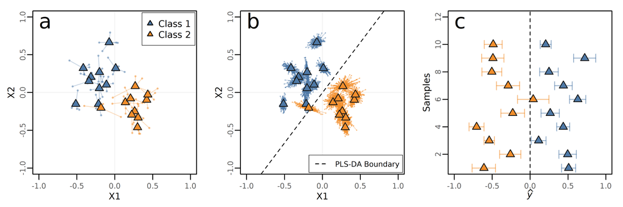

Figure 1. Uncertainty of the classification outputs for the PLS-DA model. (a) 2D data simulation. Circles represents the replicates, while the triangles represents the mean of replicates. (b) Augmented noise generated through eigen decomposition of the original covariance matrix for each sample. 50 points are showed for each sample. (c) Estimated uncertainty for each sample.

## Correlated noise

The previous examples showed how the uncertainty was estimated for Independent and Identically Distributed noise (iid noise). The next examples show how the uncertainty can be estimated for correlated noise, easily found in spectroscopy data.

### Positive covariance

For this example, the covariance between the X1 and X2 is 0.8. The results are showed in Table 2.

. .

Table 2. Results of the predict_with_uncertainty_parallel() function for variables with positive covariance.

| class | sample | y_mean | y_sd | area_above_0 | area_below_0 | classification |
| --- | --- | --- | --- | --- | --- | --- |
| Class 1 | 1 | 0.5406 | 0.0315 | 1.000 | 0.000 | Class 1 |
| Class 1 | 2 | 0.4871 | 0.0401 | 1.000 | 0.000 | Class 1 |
| Class 1 | 3 | 0.1887 | 0.0144 | 1.000 | 0.000 | Class 1 |
| Class 1 | 4 | 0.5337 | 0.0211 | 1.000 | 0.000 | Class 1 |
| Class 1 | 5 | 0.2957 | 0.0349 | 1.000 | 0.000 | Class 1 |
| Class 1 | 6 | 0.5424 | 0.0346 | 1.000 | 0.000 | Class 1 |
| Class 1 | 7 | 0.4496 | 0.0193 | 1.000 | 0.000 | Class 1 |
| Class 1 | 8 | 0.1962 | 0.0177 | 1.000 | 0.000 | Class 1 |
| Class 1 | 9 | 0.6809 | 0.0238 | 1.000 | 0.000 | Class 1 |
| Class 1 | 10 | 0.2320 | 0.0237 | 1.000 | 0.000 | Class 1 |
| Class 2 | 1 | -0.6341 | 0.0177 | 0.000 | 1.000 | Class 2 |
| Class 2 | 2 | -0.2022 | 0.0341 | 0.000 | 1.000 | Class 2 |
| Class 2 | 3 | -0.5983 | 0.0300 | 0.000 | 1.000 | Class 2 |
| Class 2 | 4 | -0.6384 | 0.0142 | 0.000 | 1.000 | Class 2 |
| Class 2 | 5 | -0.2666 | 0.0571 | 0.000 | 1.000 | Class 2 |
| Class 2 | 6 | 0.0045 | 0.0350 | 0.551 | 0.449 | Uncertain |
| Class 2 | 7 | -0.3333 | 0.0299 | 0.000 | 1.000 | Class 2 |
| Class 2 | 8 | -0.5318 | 0.0307 | 0.000 | 1.000 | Class 2 |
| Class 2 | 9 | -0.6027 | 0.0196 | 0.000 | 1.000 | Class 2 |
| Class 2 | 10 | -0.3438 | 0.0281 | 0.000 | 1.000 | Class 2 |

The results can also be visualized, as showed in Figure 2.

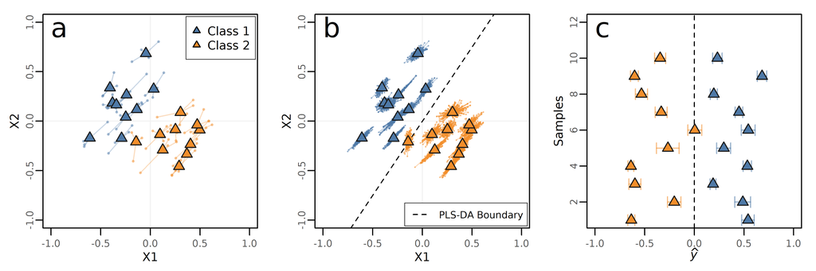

### Negative Covariance

For this example, the covariance between the X1 and X2 is -0.8. The results are showed in Table 3 and can be visualized in Figure 3.

. .

Table 3. Results of the predict_with_uncertainty_parallel() function for variables with negative covariance.

| class | sample | y_mean | y_sd | area_above_0 | area_below_0 | classification |
| --- | --- | --- | --- | --- | --- | --- |
| Class 1 | 1 | 0.5719 | 0.0618 | 1.000 | 0.000 | Class 1 |
| Class 1 | 2 | 0.4288 | 0.0579 | 1.000 | 0.000 | Class 1 |
| Class 1 | 3 | 0.1413 | 0.0890 | 0.944 | 0.056 | Uncertain |
| Class 1 | 4 | 0.4316 | 0.0902 | 1.000 | 0.000 | Class 1 |
| Class 1 | 5 | 0.2945 | 0.1363 | 0.985 | 0.015 | Class 1 |
| Class 1 | 6 | 0.5971 | 0.0729 | 1.000 | 0.000 | Class 1 |
| Class 1 | 7 | 0.4407 | 0.1167 | 1.000 | 0.000 | Class 1 |
| Class 1 | 8 | 0.2700 | 0.0712 | 1.000 | 0.000 | Class 1 |
| Class 1 | 9 | 0.6664 | 0.0696 | 1.000 | 0.000 | Class 1 |
| Class 1 | 10 | 0.1202 | 0.0653 | 0.967 | 0.033 | Uncertain |
| Class 2 | 1 | -0.5800 | 0.1028 | 0.000 | 1.000 | Class 2 |
| Class 2 | 2 | -0.2759 | 0.0879 | 0.001 | 0.999 | Class 2 |
| Class 2 | 3 | -0.5170 | 0.0757 | 0.000 | 1.000 | Class 2 |
| Class 2 | 4 | -0.7555 | 0.0861 | 0.000 | 1.000 | Class 2 |
| Class 2 | 5 | -0.2188 | 0.0956 | 0.011 | 0.989 | Class 2 |
| Class 2 | 6 | 0.0764 | 0.0591 | 0.902 | 0.098 | Uncertain |
| Class 2 | 7 | -0.2266 | 0.0691 | 0.001 | 0.999 | Class 2 |
| Class 2 | 8 | -0.4275 | 0.0789 | 0.000 | 1.000 | Class 2 |
| Class 2 | 9 | -0.4655 | 0.1157 | 0.000 | 1.000 | Class 2 |
| Class 2 | 10 | -0.5930 | 0.1204 | 0.000 | 1.000 | Class 2 |

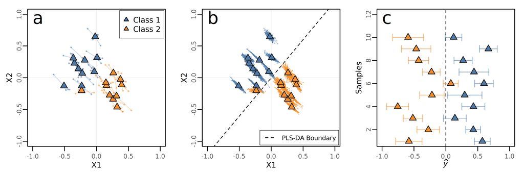

Figure 3. Uncertainty of the classification outputs for the PLS-DA model with negative covariance. (a) 2D data simulation. Circles represents the replicates, while the triangles represents the mean of replicates. (b) Augmented noise generated through eigen decomposition of the original covariance matrix for each sample. 50 points are showed for each sample. (c) Estimated uncertainty for each sample.